# Analyzing Missing Persons Data from NAMUS and NCMEC

Tutorial by Madison Powers

Motivation for this project/topic: The issue of missing persons is a signifigant and important social phenomenon. People go missing for a variety of reasons such as suicide, kidnapping, murder, escaping domestic abuse, etc. Not every missing person's case is criminal, for example some people go missing willingly. And others go missing due to accidents(hiking, drownings). Missing persons with a crimial element often include: kidnappings, child abductions, sex trafficing, murder, etc.

Because data on missing persons has really only been collected and analyzed beginning in the 20th century, there is not a long history of investigation and/or interest in missing persons cases. This is mainly because no one knew the full magnitude/scope of the problem. Now, by having all of these data available, we are able to scientifically look at the issue of mising persons.

Another reason I wanted to explore missing persons data is because often times these cases are overlooked by the general public. Due to lack of either news coverage or familarity with the missing person, these cases can easily exist under the randar of most people. Think to yourself about the most famous missing persons cases. You'll soon realize that most of these cases have an element of noterity, fame, mystery, money, or intense emotion. If the person isn't famous, or their family doesn't have the resources to publicize their case, most people won't know about them being missing.

Since we've only been able to recently explore this data in any depth, many opportunities remain to have signifigant impact on understanding the issue and bringing people home.

The National Center for Missing & Exploited Children(NCMEC): https://www.missingkids.org/HOME The National Missing and Unidentified Persons System(NamUs): https://namus.nij.ojp.gov/

The main goal of this project is to better understand missing persons data and increase awareness of this issue.

Table of Contents:

1. Data collection/curation + parsing
2. Data management/representation
3. Exploratory data analysis
4. Hypothesis testing and machine learning
5. Communication of insights attained

```python
!pip install folium  #have to install folium since it is not in the docker image
```

```python
import pandas as pd
import json
import requests
import datetime
import numpy as np
from sklearn import linear_model
from sklearn.model_selection import train_test_split
import matplotlib.pyplot as plt
import matplotlib.cm as cm
import folium
```

# Data Importing and Wrangling

For this project I will be using data from https://github.com/jcmack/missingpersons . This data derrives from The National Center for Missing & Exploited Children(NCMEC) and The National Missing and Unidentified Persons System(NamUs).Note: this dataset only focuses on missing persons cases in California. While the creator walks through a process on how to scrape data from these sites, I believe that it is a little out of the scope of this project(mainly time). As stated by the creator of the dataset, NAMUS and NCMEC don't have APIs/easy ways to access their data. Good news though, NamUs is currently working on an API. Which will make this process a lot easier in the future! Since, we're not in the future, I will be importing the data using pandas/json.

```python
URL = 'https://raw.githubusercontent.com/jcmack/missingpersons/master/data/merged_ca.json'
df = pd.read_json(URL,dtype=True)
```

```python
df = df.transpose() #have to transpose since it imports with people as columns instead of rows
```

```python
df = df.convert_dtypes() #want to have numbers instead of objects
df['date']= pd.to_datetime(df['date']) #turn dates into datetime objects to make processing/using easier
```

```python
df.dtypes  #now we have numbers and datetimes instead of just objects!
```

```
age                        Int64
aged_photo                string
agency_contact            string
agency_name               string
circumstance              string
city                      string
country                   string
county                    string
date              datetime64[ns]
eye_color                 string
first_name                string
hair_color                string
height                   float64
last_name                 string
middle_name               string
namus_number              string
ncmec_number              string
org                       string
org_contact               string
org_name                  string
photo                     string
race                      string
sex                       string
state                     string
weight                   float64
dtype: object
```

```python
df  #here's what we get after changing the types
```

|  | age | aged_photo | agency_contact | agency_name | circumstance | city | country | county | date | eye_color | ... | namus_number | ncmec_number | org | org_contact | org_name | photo | race | sex | state | weight |
| --- | --- | --- | --- | --- | --- | --- | --- | --- | --- | --- | --- | --- | --- | --- | --- | --- | --- | --- | --- | --- | --- |
| NAMUS_10005 | 55 |  | 323 890-5500 | LOS ANGELES CO. SHERIFF'S DEPT. (California) |  | Lake Hughes | US | Los Angeles | 2011-02-03 | Brown | ... | 10005 |  | NAMUS | 1-855-626-7600 | National Missing and Unidentified Persons System | https://www.findthemissing.org/en/photos/thumb... | White | Male | California | 175.0 |
| NAMUS_10014 | 34 |  | 909 356-6411 | San Bernardino County Sheriff Department (Cali... | It is believed that Larry Schafer disappeared ... | Mount Baldy | US | Los Angeles | 1982-03-14 | Brown | ... | 10014 |  | NAMUS | 1-855-626-7600 | National Missing and Unidentified Persons System |  | White | Male | California | 190.0 |
| NAMUS_10056 | 47 |  | (951) 353-7135 | Riverside Police (California) |  | Riverside | US | Riverside | 2011-02-11 | Brown | ... | 10056 |  | NAMUS | 1-855-626-7600 | National Missing and Unidentified Persons System | https://www.findthemissing.org/en/photos/thumb... | White Hispanic/Latino | Female | California | 118.0 |
| NAMUS_10087 | 38 |  | (760) 768-2140 | Calexico Police Department (California) | Date of birth is estimated. Yolanda is missing... | Calexico | US | Imperial | 2001-01-11 | Brown | ... | 10087 |  | NAMUS | 1-855-626-7600 | National Missing and Unidentified Persons System | https://www.findthemissing.org/en/photos/thumb... | White Hispanic/Latino | Female | California | 130.0 |
| NAMUS_10090 | 30 |  | 562-594-7232 | Los Alamitos Police Department (California) | Noppajan is missing with her son, Justin Lo, a... | Los Alamitos | US | Orange | 2004-10-12 | Brown | ... | 10090 |  | NAMUS | 1-855-626-7600 | National Missing and Unidentified Persons System | https://www.findthemissing.org/en/photos/thumb... | Asian or Pacific Islander | Female | California | 110.0 |
| ... | ... | ... | ... | ... | ... | ... | ... | ... | ... | ... | ... | ... | ... | ... | ... | ... | ... | ... | ... | ... | ... |
| NCMEC_982012 | 12 | http://www.missingkids.com/photographs/NCMC982... | 1-925-646-2502 | Contra Costa District Attorney's Office (Calif... | Amir's photo is shown age-progressed to 12 yea... | San Ramon | US | Contra Costa | 2003-04-30 | Brown | ... | 19490 | 982012 | NCMC | 1-800-843-5678 (1-800-THE-LOST) | National Center for Missing & Exploited Children | http://www.missingkids.com/photographs/NCMC982... | White | Male | California | 30.0 |
| NCMEC_982363 | 26 | http://www.missingkids.com/photographs/NCMC982... | 1-909-336-0600 | San Bernardino County Sheriff's Office (Califo... | The photos on the right and left are of Daniel... | Running Springs | US | San Bernardino | 2004-02-08 | Brown | ... | 6839 | 982363 | NCMC | 1-800-843-5678 (1-800-THE-LOST) | National Center for Missing & Exploited Children | http://www.missingkids.com/photographs/NCMC982... | Asian or Pacific Islander | Male | California | 125.0 |
| NCMEC_985024 | 65 | http://www.missingkids.com/photographs/NCMC985... | 1-323-526-5541 | Los Angeles County Sheriff's Office (California) | The photo on the right is a composite image of... | Altadena | US | Los Angeles | 1957-03-23 | Brown | ... | 5867 | 985024 | NCMC | 1-800-843-5678 (1-800-THE-LOST) | National Center for Missing & Exploited Children | http://www.missingkids.com/photographs/NCMC985... | White | Male | California | 50.0 |
| NCMEC_987412 | 12 | http://www.missingkids.com/photographs/NCMC987... | 1-213-974-3607 | Los Angeles County District Attorney's Office ... | Kevin's photo is shown age-progressed to 11 ye... | North Hollywood | US | Los Angeles | 2004-03-31 | Brown | ... | 19519 | 987412 | NCMC | 1-800-843-5678 (1-800-THE-LOST) | National Center for Missing & Exploited Children | http://www.missingkids.com/photographs/NCMC987... | Other | Male | California | 33.0 |
| NCMEC_991788 | 34 | http://www.missingkids.com/photographs/NCMA991... | 1-510-238-3641 | Oakland Police Department (California) | Kristen's photo is shown age-progressed to 31 ... | San Francisco | US |  | 1997-06-23 | Brown | ... | 4015 | 991788 | NCMA | SPECIAL NOTE: This case was initiated pursuant... | 5779A-National Center for Missing & Exploited ... | http://www.missingkids.com/photographs/NCMA991... | White | Female | California | 145.0 |

1339 rows × 25 columns

# Data Wrangling and Cleaning

For the purpose of this project, I will be dropping some columns of data that I will not be using. This does not mean that this data is not important, just that it is out of the scope of this project. For example, circumstance data would be really useful to analyze, possibly through natural language processing. But, once again, for the purpose of this project, I will be ommiting it. Additonally, I will be dropping: aged photo, photo, org contact, country and state. Once again, the information in these columns are extremely useful in other applications, but are out of the scope of this project. (Note: I am dropping both country and state since all of this data is for California)

The dataset is pretty clean, but there are some missing values. Some of the colums that have missing data are: middle name, namus_number, ncmec_number, county, and city. Middle names can be missing since some people don't have them or it isn't in the missing persons report. Namus number and ncmec number will be missing due to the missing person being from one database and not the other. County and city are missing for some people as well. An easy way to 'fix' this is by filling any empty strings with not available(NA)s. This will make processing easier, but this may lead to some bias when doing calculations with the data. Similar to numpy's not a number(NaN), pandas Not available will be treated as a 0 in calculations.

```python
df.drop(labels=['aged_photo','photo','circumstance','agency_contact','org_contact','country','state'],inplace=True,axis=1) #dropping columns and keeping the same dataframe
```

```python
df.replace(to_replace='',value= pd.NA, inplace=True) #empty strings-> pandas not available
```

```python
df  #see new df after dropping columns and filling in missing values with pandas not available
```

|  | age | agency_name | city | county | date | eye_color | first_name | hair_color | height | last_name | middle_name | namus_number | ncmec_number | org | org_name | race | sex | weight |
| --- | --- | --- | --- | --- | --- | --- | --- | --- | --- | --- | --- | --- | --- | --- | --- | --- | --- | --- |
| NAMUS_10005 | 55 | LOS ANGELES CO. SHERIFF'S DEPT. (California) | Lake Hughes | Los Angeles | 2011-02-03 | Brown | Dennis | Brown | 71.0 | Dobrovolny | Paul | 10005 | <NA> | NAMUS | National Missing and Unidentified Persons System | White | Male | 175.0 |
| NAMUS_10014 | 34 | San Bernardino County Sheriff Department (Cali... | Mount Baldy | Los Angeles | 1982-03-14 | Brown | Larry | Brown | 73.0 | Schafer | Duane | 10014 | <NA> | NAMUS | National Missing and Unidentified Persons System | White | Male | 190.0 |
| NAMUS_10056 | 47 | Riverside Police (California) | Riverside | Riverside | 2011-02-11 | Brown | Ilma | Black | 60.0 | Saucedo | J | 10056 | <NA> | NAMUS | National Missing and Unidentified Persons System | White Hispanic/Latino | Female | 118.0 |
| NAMUS_10087 | 38 | Calexico Police Department (California) | Calexico | Imperial | 2001-01-11 | Brown | Yolanda | Black | 63.0 | Patlan | <NA> | 10087 | <NA> | NAMUS | National Missing and Unidentified Persons System | White Hispanic/Latino | Female | 130.0 |
| NAMUS_10090 | 30 | Los Alamitos Police Department (California) | Los Alamitos | Orange | 2004-10-12 | Brown | Noppajan | Black | 63.0 | Lo | <NA> | 10090 | <NA> | NAMUS | National Missing and Unidentified Persons System | Asian or Pacific Islander | Female | 110.0 |
| ... | ... | ... | ... | ... | ... | ... | ... | ... | ... | ... | ... | ... | ... | ... | ... | ... | ... | ... |
| NCMEC_982012 | 12 | Contra Costa District Attorney's Office (Calif... | San Ramon | Contra Costa | 2003-04-30 | Brown | Amir | Black | 24.0 | Abdou | Kareem | 19490 | 982012 | NCMC | National Center for Missing & Exploited Children | White | Male | 30.0 |
| NCMEC_982363 | 26 | San Bernardino County Sheriff's Office (Califo... | Running Springs | San Bernardino | 2004-02-08 | Brown | Daniel | Black | 66.0 | Yuen | Ted | 6839 | 982363 | NCMC | National Center for Missing & Exploited Children | Asian or Pacific Islander | Male | 125.0 |
| NCMEC_985024 | 65 | Los Angeles County Sheriff's Office (California) | Altadena | Los Angeles | 1957-03-23 | Brown | Thomas | Blonde | 48.0 | Bowman | Eldon | 5867 | 985024 | NCMC | National Center for Missing & Exploited Children | White | Male | 50.0 |
| NCMEC_987412 | 12 | Los Angeles County District Attorney's Office ... | North Hollywood | Los Angeles | 2004-03-31 | Brown | Kevin | Brown | 36.0 | Anderson | Dray | 19519 | 987412 | NCMC | National Center for Missing & Exploited Children | Other | Male | 33.0 |
| NCMEC_991788 | 34 | Oakland Police Department (California) | San Francisco | <NA> | 1997-06-23 | Brown | Kristen | Brown | 68.0 | Modafferi | <NA> | 4015 | 991788 | NCMA | 5779A-National Center for Missing & Exploited ... | White | Female | 145.0 |

1339 rows × 18 columns

# Data Exploration Part 1

When looking at this data, one of the first questions that came to mind was does the number of missing persons correlate to population? I would expect the answer to be yes: more people, more missing people. This may seem pointless but, it is still important to take a look at this and see if there is anything out of the ordinary. If everything comes out as expected, I can move onto the next step, but if an outlier appears or something looks 'off' it might be worth it to investigate!

At first, I wanted to create a choropleth map of California using folium and coloring it based on number of missing persons, since visualizing the data in this way would make it easier to understand. I tried to use the county geometry I got from https://gis.data.ca.gov/datasets/CDTFA::city-and-county-boundaries/api , but could not get it to work due to the shape of the array. So this version of this project will not include this but hopefully a future version will.

[figure not shown]

```python
fig,axes = plt.subplots(1,2,figsize=(15,5))
#preparing a figure so that I can plot later
```

# More Data Importing and Cleaning!

In order to look at the relation between population and missing persons, I need population data! I was able to get California county population data from https://www.counties.org/post/datapile (California State Association of Counties). It was only available as an excel spreadsheet, so I downloaded it and imported it into my Jupyter notebook. Then using Panda's read_excel function I was able to get all of the data in a nice dataframe! Before I can start using the data, I need to clean it, in this case there are no missing values but, there are values that I do not need. Since the missing persons data only goes up to 2014, I will drop the data from 2015 onward. And since the county population data starts at 1970, I will create a dataframe with missing persons from 1970 onward.

```python
county_pop = pd.read_excel('population_by_jurisdiction_and_by_county_-_1970_to_2018_-_09-07-2018.xlsx') #population data for california counties from 1970 to 2018
```

```python
#need to do two things, drop 2015-2018, and group by year
drop_ind = county_pop[county_pop['Year'] >= 2015].index #getting indicies of the rows where the year is 2015-2018
```

```python
county_pop.drop(drop_ind, inplace=True) #dropping unneeded years
```

```python
county_pop
```

|  | County | Jurisdiction | Year | Population |
| --- | --- | --- | --- | --- |
| 0 | Alameda | Alameda | 1970 | 70968 |
| 1 | Alameda | Albany | 1970 | 15561 |
| 2 | Alameda | Berkeley | 1970 | 114091 |
| 3 | Alameda | Dublin | 1970 | 0 |
| 4 | Alameda | Emeryville | 1970 | 2681 |
| ... | ... | ... | ... | ... |
| 24291 | Yolo | Winters | 2014 | 6898 |
| 24292 | Yolo | Woodland | 2014 | 57671 |
| 24293 | Yuba | Marysville | 2014 | 11971 |
| 24294 | Yuba | Unincorporated Yuba | 2014 | 58262 |
| 24295 | Yuba | Wheatland | 2014 | 3413 |

24296 rows × 4 columns

```python
drop_ind = df[df['date'] < '1970'].index #getting indicies of the rows where the year is less than 1970
```

```python
#creating a dataframe that only has cases from 1970 or later to match with the county pop data
df_70 = df.drop(drop_ind)
```

```python
df_70 = pd.DataFrame(df_70.groupby(df['date'].dt.year))
df_70['total_missing'] = ""
for i in range(len(df_70)): #summing missing persons for each year
    df_70.at[i,'total_missing']=df_70.at[i,1].shape[0]
```

```python
df_70
```

|  | 0 | 1 | total_missing |
| --- | --- | --- | --- |
| 0 | 1970 | age ... | 5 |
| 1 | 1971 | age ... | 7 |
| 2 | 1972 | age ... | 8 |
| 3 | 1973 | age ... | 14 |
| 4 | 1974 | age ... | 6 |
| 5 | 1975 | age ... | 7 |
| 6 | 1976 | age ... | 15 |
| 7 | 1977 | age ... | 19 |
| 8 | 1978 | age ... | 16 |
| 9 | 1979 | age ... | 19 |
| 10 | 1980 | age ... | 19 |
| 11 | 1981 | age ... | 30 |
| 12 | 1982 | age ... | 28 |
| 13 | 1983 | age ... | 26 |
| 14 | 1984 | age ... | 24 |
| 15 | 1985 | age ... | 18 |
| 16 | 1986 | age ... | 28 |
| 17 | 1987 | age ... | 25 |
| 18 | 1988 | age ... | 30 |
| 19 | 1989 | age ... | 20 |
| 20 | 1990 | age ... | 18 |
| 21 | 1991 | age ... | 25 |
| 22 | 1992 | age ... | 19 |
| 23 | 1993 | age ... | 35 |
| 24 | 1994 | age ... | 28 |
| 25 | 1995 | age ... | 28 |
| 26 | 1996 | age ... | 36 |
| 27 | 1997 | age ... | 42 |
| 28 | 1998 | age ... | 34 |
| 29 | 1999 | age ... | 32 |
| 30 | 2000 | age ... | 26 |
| 31 | 2001 | age ... | 26 |
| 32 | 2002 | age ... | 22 |
| 33 | 2003 | age ... | 31 |
| 34 | 2004 | age ... | 35 |
| 35 | 2005 | age ... | 47 |
| 36 | 2006 | age ... | 38 |
| 37 | 2007 | age ... | 43 |
| 38 | 2008 | age ... | 40 |
| 39 | 2009 | age ... | 38 |
| 40 | 2010 | age ... | 36 |
| 41 | 2011 | age ... | 66 |
| 42 | 2012 | age ... | 73 |
| 43 | 2013 | age ... | 94 |
| 44 | 2014 | age ... | 30 |

```python
countyGBY = pd.DataFrame(county_pop.groupby('Year'))
```

```python
for i in range(len(countyGBY)): #summing missing persons for each month
    countyGBY.at[i,'total_pop']=countyGBY.at[i,1]['Population'].sum()
```

```python
axes[0].plot(countyGBY[0],countyGBY['total_pop']) #plotting total pop vs year
axes[0].set_xlabel("Year")
axes[0].set_ylabel("Total Population")
axes[0].set_title("Population vs Year")
```

```python
axes[1].plot(df_70[0],df_70['total_missing'], color = 'red')  #plotting total missing vs year
axes[1].set_xlabel("Year")
axes[1].set_ylabel("Total Missing Persons")
axes[1].set_title("Missing Persons vs Year")
```

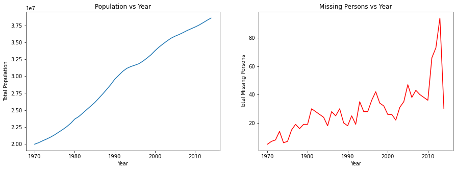

```python
fig
```

# Summary and Conclusions from Part 1

When looking at the graphs its clear that as time goes on, population increases and so does the number of missing persons. One thing to point out about the second graph is that the overall trend is that the number of missing persons increases but, per year it varies and even decreases at some points.

# Data Exploration Part 2

In this second part, I wanted to explore how age relates to number of missing persons. Do teens go missing more? Do senior citizens go missing more? Is there even a relationship between age and missing persons? These are some of the questions that come to mind that I want to explore.

According to NCMEC, in 2020, 91% of missing childrens cases were endangered runaways(https://www.missingkids.org/footer/media/keyfacts). From this, I would expect, that the number of missing teen/young adults would be larger than the number of missing children(0-12).

In order to organize this data for visualization, I will be using pandas.cut to create bins. When binning data, you can create bins with the same number of data or bins with the same range of data. For the purpose of age, I will be splitting the data into 4 bins: children(0-12), teens/young adults(12-20), adults(20-65), and seniors(65+). The reason for this disctinction is to focus on the 'main' groups of people. You could group people differently, and you might gain some new insight. Additionally, the teens/young adults bin ends at 20 because NCMEC includes people 20 and younger. See: https://www.missingkids.org/content/dam/missingkids/pdfs/publications/nc74.pdf (pg 37 of pdf/ Missing and Abducted Children - 19)

[figure not shown]

```python
fig,ax = plt.subplots(figsize=(10,7))
```

```python
#creating age bins using cut and adding to df
df['age_bin'] = pd.cut(df['age'],bins=[0,12,20,65,df['age'].max()],labels=['Child','Teen','Adult','Senior'],include_lowest=True) #note to self: can add conditions to first parameter to change age range
```

```python
df
```

|  | age | agency_name | city | county | date | eye_color | first_name | hair_color | height | last_name | middle_name | namus_number | ncmec_number | org | org_name | race | sex | weight | age_bin |
| --- | --- | --- | --- | --- | --- | --- | --- | --- | --- | --- | --- | --- | --- | --- | --- | --- | --- | --- | --- |
| NAMUS_10005 | 55 | LOS ANGELES CO. SHERIFF'S DEPT. (California) | Lake Hughes | Los Angeles | 2011-02-03 | Brown | Dennis | Brown | 71.0 | Dobrovolny | Paul | 10005 | <NA> | NAMUS | National Missing and Unidentified Persons System | White | Male | 175.0 | Adult |
| NAMUS_10014 | 34 | San Bernardino County Sheriff Department (Cali... | Mount Baldy | Los Angeles | 1982-03-14 | Brown | Larry | Brown | 73.0 | Schafer | Duane | 10014 | <NA> | NAMUS | National Missing and Unidentified Persons System | White | Male | 190.0 | Adult |
| NAMUS_10056 | 47 | Riverside Police (California) | Riverside | Riverside | 2011-02-11 | Brown | Ilma | Black | 60.0 | Saucedo | J | 10056 | <NA> | NAMUS | National Missing and Unidentified Persons System | White Hispanic/Latino | Female | 118.0 | Adult |
| NAMUS_10087 | 38 | Calexico Police Department (California) | Calexico | Imperial | 2001-01-11 | Brown | Yolanda | Black | 63.0 | Patlan | <NA> | 10087 | <NA> | NAMUS | National Missing and Unidentified Persons System | White Hispanic/Latino | Female | 130.0 | Adult |
| NAMUS_10090 | 30 | Los Alamitos Police Department (California) | Los Alamitos | Orange | 2004-10-12 | Brown | Noppajan | Black | 63.0 | Lo | <NA> | 10090 | <NA> | NAMUS | National Missing and Unidentified Persons System | Asian or Pacific Islander | Female | 110.0 | Adult |
| ... | ... | ... | ... | ... | ... | ... | ... | ... | ... | ... | ... | ... | ... | ... | ... | ... | ... | ... | ... |
| NCMEC_982012 | 12 | Contra Costa District Attorney's Office (Calif... | San Ramon | Contra Costa | 2003-04-30 | Brown | Amir | Black | 24.0 | Abdou | Kareem | 19490 | 982012 | NCMC | National Center for Missing & Exploited Children | White | Male | 30.0 | Child |
| NCMEC_982363 | 26 | San Bernardino County Sheriff's Office (Califo... | Running Springs | San Bernardino | 2004-02-08 | Brown | Daniel | Black | 66.0 | Yuen | Ted | 6839 | 982363 | NCMC | National Center for Missing & Exploited Children | Asian or Pacific Islander | Male | 125.0 | Adult |
| NCMEC_985024 | 65 | Los Angeles County Sheriff's Office (California) | Altadena | Los Angeles | 1957-03-23 | Brown | Thomas | Blonde | 48.0 | Bowman | Eldon | 5867 | 985024 | NCMC | National Center for Missing & Exploited Children | White | Male | 50.0 | Adult |
| NCMEC_987412 | 12 | Los Angeles County District Attorney's Office ... | North Hollywood | Los Angeles | 2004-03-31 | Brown | Kevin | Brown | 36.0 | Anderson | Dray | 19519 | 987412 | NCMC | National Center for Missing & Exploited Children | Other | Male | 33.0 | Child |
| NCMEC_991788 | 34 | Oakland Police Department (California) | San Francisco | <NA> | 1997-06-23 | Brown | Kristen | Brown | 68.0 | Modafferi | <NA> | 4015 | 991788 | NCMA | 5779A-National Center for Missing & Exploited ... | White | Female | 145.0 | Adult |

1339 rows × 19 columns

```python
gbadf = pd.DataFrame(df.groupby(by='age_bin'))
gbadf['total_missing'] = '' #init col
for i in range(len(gbadf)): #summing missing persons for each age group
    gbadf.at[i,'total_missing']=gbadf.at[i,1].shape[0]
```

```python
ax.clear() #clearing axis
ax.bar(gbadf[0],gbadf['total_missing'], color = cm.spring(np.linspace(0, 1, len(gbadf))))
ax.set_xlabel("Age Group")
ax.set_ylabel("Number of Missing Persons")
ax.set_title("Missing Persons vs Age Group (1955-2014)")
```

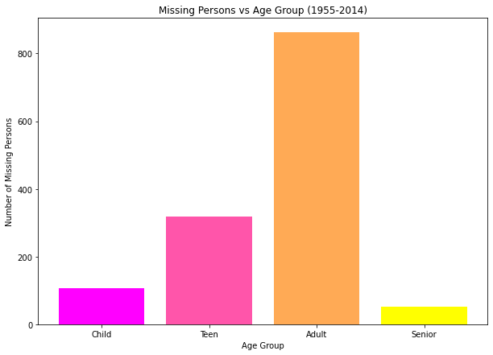

```python
fig
```

While this graph helps to show that adults between 20 and 65 go missing the most, because the range for adults is so large, it is hard to see a bigger pattern. Beacuse of this, I want to instead try making bins of equal sizes and seeing if it is easier to see a pattern and gain insight that way. In this case, I am splitting ages in to 10 bins which are 9 years 'long'.

```python
df['small_bin'] = pd.cut(df['age'],bins=10,labels=['0-9','9-18','18-28','28-37','37-47','47-56','56-65','65-75','75-83','83-93'],include_lowest=True)
```

```python
df
```

|  | age | agency_name | city | county | date | eye_color | first_name | hair_color | height | last_name | middle_name | namus_number | ncmec_number | org | org_name | race | sex | weight | age_bin | small_bin |
| --- | --- | --- | --- | --- | --- | --- | --- | --- | --- | --- | --- | --- | --- | --- | --- | --- | --- | --- | --- | --- |
| NAMUS_10005 | 55 | LOS ANGELES CO. SHERIFF'S DEPT. (California) | Lake Hughes | Los Angeles | 2011-02-03 | Brown | Dennis | Brown | 71.0 | Dobrovolny | Paul | 10005 | <NA> | NAMUS | National Missing and Unidentified Persons System | White | Male | 175.0 | Adult | 47-56 |
| NAMUS_10014 | 34 | San Bernardino County Sheriff Department (Cali... | Mount Baldy | Los Angeles | 1982-03-14 | Brown | Larry | Brown | 73.0 | Schafer | Duane | 10014 | <NA> | NAMUS | National Missing and Unidentified Persons System | White | Male | 190.0 | Adult | 28-37 |
| NAMUS_10056 | 47 | Riverside Police (California) | Riverside | Riverside | 2011-02-11 | Brown | Ilma | Black | 60.0 | Saucedo | J | 10056 | <NA> | NAMUS | National Missing and Unidentified Persons System | White Hispanic/Latino | Female | 118.0 | Adult | 47-56 |
| NAMUS_10087 | 38 | Calexico Police Department (California) | Calexico | Imperial | 2001-01-11 | Brown | Yolanda | Black | 63.0 | Patlan | <NA> | 10087 | <NA> | NAMUS | National Missing and Unidentified Persons System | White Hispanic/Latino | Female | 130.0 | Adult | 37-47 |
| NAMUS_10090 | 30 | Los Alamitos Police Department (California) | Los Alamitos | Orange | 2004-10-12 | Brown | Noppajan | Black | 63.0 | Lo | <NA> | 10090 | <NA> | NAMUS | National Missing and Unidentified Persons System | Asian or Pacific Islander | Female | 110.0 | Adult | 28-37 |
| ... | ... | ... | ... | ... | ... | ... | ... | ... | ... | ... | ... | ... | ... | ... | ... | ... | ... | ... | ... | ... |
| NCMEC_982012 | 12 | Contra Costa District Attorney's Office (Calif... | San Ramon | Contra Costa | 2003-04-30 | Brown | Amir | Black | 24.0 | Abdou | Kareem | 19490 | 982012 | NCMC | National Center for Missing & Exploited Children | White | Male | 30.0 | Child | 9-18 |
| NCMEC_982363 | 26 | San Bernardino County Sheriff's Office (Califo... | Running Springs | San Bernardino | 2004-02-08 | Brown | Daniel | Black | 66.0 | Yuen | Ted | 6839 | 982363 | NCMC | National Center for Missing & Exploited Children | Asian or Pacific Islander | Male | 125.0 | Adult | 18-28 |
| NCMEC_985024 | 65 | Los Angeles County Sheriff's Office (California) | Altadena | Los Angeles | 1957-03-23 | Brown | Thomas | Blonde | 48.0 | Bowman | Eldon | 5867 | 985024 | NCMC | National Center for Missing & Exploited Children | White | Male | 50.0 | Adult | 56-65 |
| NCMEC_987412 | 12 | Los Angeles County District Attorney's Office ... | North Hollywood | Los Angeles | 2004-03-31 | Brown | Kevin | Brown | 36.0 | Anderson | Dray | 19519 | 987412 | NCMC | National Center for Missing & Exploited Children | Other | Male | 33.0 | Child | 9-18 |
| NCMEC_991788 | 34 | Oakland Police Department (California) | San Francisco | <NA> | 1997-06-23 | Brown | Kristen | Brown | 68.0 | Modafferi | <NA> | 4015 | 991788 | NCMA | 5779A-National Center for Missing & Exploited ... | White | Female | 145.0 | Adult | 28-37 |

1339 rows × 20 columns

```python
gba2df = pd.DataFrame(df.groupby(by='small_bin'))
gba2df['total_missing'] = '' #init col
for i in range(len(gba2df)): #summing missing persons for each age group
    gba2df.at[i,'total_missing']=gba2df.at[i,1].shape[0]
```

```python
gba2df
```

|  | 0 | 1 | total_missing |
| --- | --- | --- | --- |
| 0 | 0-9 | age ... | 79 |
| 1 | 9-18 | age ... | 250 |
| 2 | 18-28 | age ... | 321 |
| 3 | 28-37 | age ... | 264 |
| 4 | 37-47 | age ... | 175 |
| 5 | 47-56 | age ... | 129 |
| 6 | 56-65 | age ... | 68 |
| 7 | 65-75 | age ... | 29 |
| 8 | 75-83 | age ... | 18 |
| 9 | 83-93 | age ... | 6 |

```python
ax.clear() #cleaning axis
ax.bar(gba2df[0],gba2df['total_missing'], color = cm.spring(np.linspace(0, 1, len(gbadf))))
ax.set_xlabel("Age Group")
ax.set_ylabel("Number of Missing Persons")
ax.set_title("Missing Persons vs Age Group (1955-2014)")
```

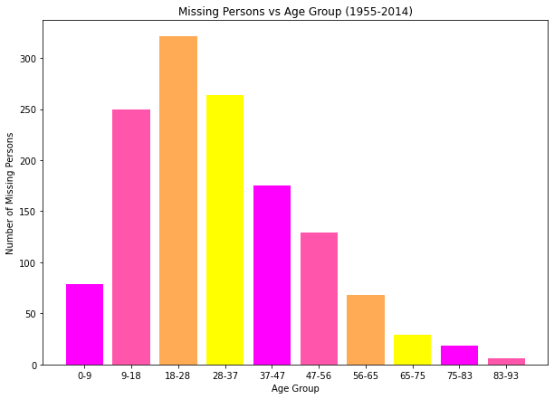

```python
fig
```

# Summary and Conclusions from Part 2

While the first graph helped demonstrate that teens and young adults go missing more than children and adults go missing more than seniors, it was hard to see any other patterns. By making the bins smaller and evenly sized, it was easier to see what age groups go missing the most, people aged 9-18,18-28, and 28-37 are the age groups with the most missing persons. This graph also helps to show there is a relationship between age and being missing.

# Data Exploration Part 3

The last exploration I wanted to do in this project is to examine the number of missing persons vs time of year. Do people go missing more during a certain season or holiday?

```python
gbmdf = pd.DataFrame(df.groupby(df['date'].dt.month)) #grouping by month
```

```python
for i in range(len(gbmdf)): #summing missing persons for each month
    gbmdf.at[i,'total_missing']=gbmdf.at[i,1].shape[0]
```

```python
gbmdf
```

|  | 0 | 1 | total_missing |
| --- | --- | --- | --- |
| 0 | 1 | age ... | 127.0 |
| 1 | 2 | age ... | 104.0 |
| 2 | 3 | age ... | 123.0 |
| 3 | 4 | age ... | 96.0 |
| 4 | 5 | age ... | 112.0 |
| 5 | 6 | age ... | 109.0 |
| 6 | 7 | age ... | 137.0 |
| 7 | 8 | age ... | 113.0 |
| 8 | 9 | age ... | 85.0 |
| 9 | 10 | age ... | 119.0 |
| 10 | 11 | age ... | 97.0 |
| 11 | 12 | age ... | 117.0 |

```python
ax.clear() #clearing for next graph
```

```python
ax.bar(gbmdf[0],gbmdf['total_missing'],color = cm.plasma(np.linspace(0, 1, len(gbmdf))))
ax.set_xlabel("Month")
ax.set_xticks(range(1,13))
ax.set_ylabel("Number of Missing Persons")
ax.set_title("Missing Persons vs Month (1955-2014)")
```

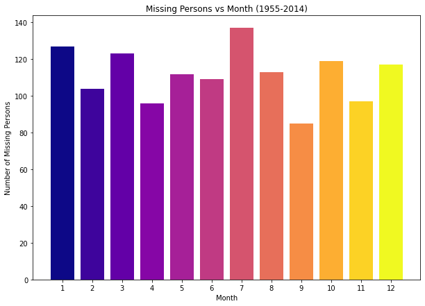

```python
fig
```

# Summary and Conclusions from Part 3

A few things to note about this graph:

My 'hunches'/guesses were incorrect! Besides the maximum in July, it seems that in most months between 80-120 people go missing. There are a lot of things that could explain this pattern. For the peak in July, one of the reasons that it could be that way is that people go hiking and are outdoors more in the summer. For the overall pattern, this makes a lot of sense when you look at the reasons as to why people go missing! As noted before, a majority of missing childrens cases are runaways/endangered chilren. Adult missing cases are a little more complicated and there are more reasons as to why people are missing. A lot of the reasons are not dependent on time of year: crimes, suicides, voluntary disappearances, etc. In conclusion, time of year seems to have little effect on the number of people going missing.

-https://missingpersonsinformation.ca/resources/reasons-why-adults-go-missing/ -https://en.wikipedia.org/wiki/Missing_person#Reasons -https://www.missingpeople.org.uk/key-facts-about-missing